# Simulation of microbial progression rates

Nicholas Croucher

25/11/2021

## Data used for simulations

```r
n_types <- 20
n_studies <- 20

# Fixed for reproducibility - generated with the command `runif(n_types * n_studies, min = 0.0, max = 0.05)`
random_frequencies <- c(0.0112854470848106, 0.0187007322674617, 0.0311348387273029,
0.0201701742364094, 0.0280110965948552, 0.0375650248024613, 0.00604447952937335,
0.0131160578341223, 0.0380126537522301, 0.0199922866304405, 0.0221398023655638,
0.0166020662058145, 0.0197969890898094, 0.0403149801190011, 0.023370838642586,
0.033223592187278, 0.0185184107744135, 0.0366496772738174, 0.013176560564898,
0.0268603438511491, 0.0170564980013296, 0.0448135523707606, 0.029134395881556,
0.0263401338947006, 0.0261096181464382, 0.0255095961503685, 0.0148207693942823,
0.0311727489461191, 0.0167740020086057, 0.0474750041146763, 0.00322461153846234,
0.0110048209433444, 0.0149697809829377, 0.00206831324612722,
0.033238280354999, 0.0467834593378939, 0.0170373226050287, 0.0334277883172035,
0.0188225510530174, 0.0265777291497216, 0.0336028082063422, 0.0244762744288892,
0.00901660424424335, 0.0285989120951854, 0.0213617462897673,
0.0327196787926368, 0.0189855191390961, 0.0365497993887402, 0.0222931793774478,
0.0344638691516593, 0.0473045348771848, 0.0275668352260254, 0.0103936022846028,
0.0199861095286906, 0.00966712676454336, 0.0431243154220283,
0.0226503554149531, 0.0320369592867792, 0.0184173285146244, 0.0462511372403242,
0.00780825280817226, 0.0173906326526776, 0.046042182657402, 0.0261200602748431,
0.0272989263758063, 0.00152216666610912, 0.0131516180816107,
0.0319843380129896, 0.0414867667015642, 0.0378625916433521, 0.0290876035462134,
0.0172185215516947, 0.0421069047180936, 0.0097018611850217, 0.00102687964681536,
0.0253014724468812, 0.0145364116993733, 0.0057240700814873, 0.0323238699813373,
0.0248379262862727, 0.0209774059941992, 0.00839227006072179,
0.000815082713961601, 0.00835843909299001, 0.0452342266100459,
0.0371694131172262, 0.00725571844959632, 0.00513721997849643,
0.00633085073204711, 0.00811492785578594, 0.0298955515958369,
0.0200569947366603, 0.038988624245394, 0.0348119726404548, 0.00790411505149677,
0.00368049623211846, 0.0421765157370828, 0.014566557854414, 0.0365241808933206,
0.0324071065173484, 0.0366301609901711, 0.0434403889928944, 0.0155695946188644,
0.014461904251948, 0.00767266543116421, 0.00334490947425365,
0.0226653725956567, 0.00876490221126005, 0.0385092541109771,
0.0348551340983249, 0.0049954458954744, 0.0178003755863756, 0.00593857018975541,
0.0253478431259282, 0.0253032537177205, 0.0354388283914886, 0.0389099000953138,
0.0107885019155219, 0.00478201461955905, 0.00965272795874626,
0.0226467557135038, 0.00285583770601079, 0.0262474891380407,
0.0480387703981251, 0.0466239742701873, 0.0288450446096249, 0.0105980074265972,
0.0209669805830345, 0.0269708277075551, 0.0460666783154011, 0.0195556998602115,
0.0353456943994388, 0.032802157709375, 0.0179758346057497, 0.0193514962564223,
0.0417565047275275, 0.00180372057948262, 0.0175963953253813,
0.0326065520406701, 0.0306057025911286, 0.0244797128601931, 0.0389405019115657,
0.00627075150841847, 0.0244550334173255, 0.0289731955388561,
0.0154362588422373, 0.0393108951393515, 0.00217203859938309,
0.0220791598316282, 0.0190714539494365, 0.0422822709311731, 0.00951074230251834,
0.0117925990722142, 0.0111012336448766, 0.030641111091245, 0.0328600553330034,
0.014452387066558, 0.0275969100184739, 0.0180722309276462, 0.0213001633295789,
0.0413058013888076, 0.00206934002926573, 0.0111502067069523,
0.0363874163012952, 0.0405077884555794, 0.0409669260494411, 0.0394435907481238,
0.0346825369400904, 0.0454266948276199, 0.0278246997506358, 0.0220290031516925,
0.0285597340553068, 0.0215621337643825, 0.045790169085376, 0.0107161981752142,
0.0478521265438758, 0.00148471924476326, 0.0349755512899719,
0.0161152612767182, 0.0481614385847934, 0.0273652000701986, 0.0160709890536964,
0.0216391602763906, 0.0160359618952498, 0.0225150528131053, 0.0123395793489181,
0.0466509378515184, 0.03214583984809, 0.0438130235881545, 0.0498700820258819,
0.0192799343727529, 0.0190507285995409, 0.00710169539088383,
0.038301690784283, 0.0401157875428908, 0.0399076653993689, 0.0443770312820561,
0.00385477303061634, 0.0225021968130022, 0.0352852548006922,
0.0387871787883341, 0.0406620534951799, 0.0201268206350505, 0.00992618574528024,
0.0193602862069383, 0.021972907660529, 0.0148243866977282, 0.0174799168016762,
0.0491288382792845, 0.0149792475393042, 0.0315820503863506, 0.0447678968659602,
0.023750681092497, 0.0108494431362487, 0.0169482059776783, 0.0178158624912612,
0.0478769429959357, 0.0338811380672269, 0.0331156545551494, 0.00078089190647006,
0.00193639055360109, 0.0101450332324021, 0.0221783939749002,
0.0163031119154766, 0.0466493893414736, 0.0103397569386289, 0.000470604887232184,
0.0251343423500657, 0.0021907752729021, 0.00119928912026808,
0.00933019460644573, 0.0437862931517884, 0.00442743916064501,
0.0259286603890359, 0.000375502742826939, 0.044115668348968,
0.0107004809542559, 0.0348091494524851, 0.0287930226069875, 0.0160098047810607,
0.0498587215435691, 0.0270417573279701, 0.0128375472151674, 0.0312346979160793,
0.030664656299632, 0.0222687882953323, 0.0184752616798505, 0.0156859429203905,
0.00730722475564107, 0.0127133302506991, 0.0214902341947891,
0.0461594688124023, 0.0381562421564013, 0.00716787463752553,
0.0457901517860591, 0.0139595358865336, 0.0325180434039794, 0.0199007091345266,
0.00134449821198359, 0.0467773405835032, 0.0407984276069328,
0.0388909794623032, 0.0104968177620322, 0.0451441140146926, 0.000658522057347,
0.0161690928624012, 0.000263758283108473, 0.00934653067961335,
0.0153738715453073, 0.0454277062206529, 0.03768804022111, 0.0488853958435357,
0.0306186548201367, 0.00088116736151278, 0.0207748799701221,
0.0054849271196872, 0.0129927619476803, 0.00679626687197015,
0.0209194550057873, 0.00992383566917852, 0.0406298694084399,
0.0435337159316987, 0.0181038612150587, 0.0334876036387868, 0.0283870192826726,
0.00644122087396681, 0.0141377399442717, 0.0187047396670096,
0.0295047908555716, 0.0180219726869836, 0.019383436627686, 0.00953199919313192,
0.0469383541028947, 0.00329575131181628, 0.0430002993438393,
0.0102727616322227, 0.0374090362689458, 0.00951141429832205,
0.0218678666977212, 0.040400779072661, 0.026648454729002, 0.0465423404355533,
0.0338084432063624, 0.0245992995449342, 0.00907772053033114,
0.0246840696781874, 0.0372187620843761, 0.0192110556759872, 0.0472978672478348,
0.0363286517909728, 0.00919868308119476, 0.0127787054982036,
0.0318805902148597, 0.0414940065005794, 0.0171419179881923, 0.0480628249817528,
0.0107918045017868, 0.0476278111920692, 0.0471822133986279, 0.00535884634591639,
0.00662427266361192, 0.0213633304578252, 0.0432015463477001,
0.0358300561783835, 0.00575163864996284, 0.0232007283251733,
0.00459088748320937, 0.0306101255817339, 0.0117285119951703,
0.00285977047169581, 0.0204314406728372, 0.0470483106095344,
0.0267221117275767, 0.000221723271533847, 0.00324548992794007,
0.0324043501284905, 0.0187264877022244, 0.0144758507958613, 0.0354253637255169,
0.00313681007828563, 0.00867427835473791, 0.00105663759168237,
0.0101592514198273, 0.0136864879867062, 0.00505869922926649,
0.0278815632569604, 0.0434285752940923, 0.0262446497217752, 0.0482543976511806,
0.0321718162158504, 0.0248872927273624, 0.0211282997275703, 0.0250525951618329,
0.049292249744758, 0.0289645912591368, 0.0388347331434488, 0.00886241937987506,
0.0239166029146872, 0.0427210143185221, 0.0338977974257432, 0.00933601129800081,
0.027800206025131, 0.0160108744748868, 0.0384261836181395, 0.0422829467919655,
0.027208015974611, 0.0231970636756159, 0.00653759140986949, 0.0341588510549627,
0.0329925606842153, 0.0136631159228273, 0.0494475494837388, 0.0436314507503994,
0.0341372187132947, 0.0430898905615322, 0.0122905558091588, 0.0388792082667351,
0.0397267847205512, 0.030862283683382, 0.00963145637651906, 0.0448381626512855,
0.0465700293309055, 0.026123992074281, 0.039794942678418, 0.0323669512756169,
0.0248235378647223, 0.0298922356683761, 0.0194940955610946, 0.0423122482257895,
0.00705590611323714, 0.0456907770596445, 0.0326749510713853,
0.00209690167102963, 0.0175389529322274, 0.00198008933803067,
0.0310135266277939, 0.0201534740044735, 0.0231940337456763, 0.0212031129514799,
0.0346470220363699)

carriage_prevalences <-
  tibble(
    "type" = factor(rep(paste0("Type_",1:n_types),n_studies), levels = paste0("Type_",1:n_types)),
    "study" = factor(rep(paste0("Location_",LETTERS[1:n_studies]), each = n_types)),
    "rho_ij" = random_frequencies
  )

carriage_prevalences %>%
  kableExtra::kable()  %>%
  kableExtra::kable_styling(latex_options = "scale_down")
```

| type | study | rho_ij |
| --- | --- | --- |
| Type_1 | Location_A | 0.0112854 |
| Type_2 | Location_A | 0.0187007 |
| Type_3 | Location_A | 0.0311348 |
| Type_4 | Location_A | 0.0201702 |
| Type_5 | Location_A | 0.0280111 |
| Type_6 | Location_A | 0.0375650 |
| Type_7 | Location_A | 0.0060445 |
| Type_8 | Location_A | 0.0131161 |
| Type_9 | Location_A | 0.0380127 |
| Type_10 | Location_A | 0.0199923 |
| Type_11 | Location_A | 0.0221398 |
| Type_12 | Location_A | 0.0166021 |
| Type_13 | Location_A | 0.0197970 |
| Type_14 | Location_A | 0.0403150 |
| Type_15 | Location_A | 0.0233708 |
| Type_16 | Location_A | 0.0332236 |
| Type_17 | Location_A | 0.0185184 |
| Type_18 | Location_A | 0.0366497 |
| Type_19 | Location_A | 0.0131766 |
| Type_20 | Location_A | 0.0268603 |
| Type_1 | Location_B | 0.0170565 |
| Type_2 | Location_B | 0.0448136 |
| Type_3 | Location_B | 0.0291344 |
| Type_4 | Location_B | 0.0263401 |
| Type_5 | Location_B | 0.0261096 |
| Type_6 | Location_B | 0.0255096 |
| Type_7 | Location_B | 0.0148208 |
| Type_8 | Location_B | 0.0311727 |
| Type_9 | Location_B | 0.0167740 |
| Type_10 | Location_B | 0.0474750 |

[output cut: 370 more lines]

The progression rates for the types ($\nu_j$) are also set to either be constant (null model) or vary by type:

```r
# Fixed for reproducibility - generated with the command `10**(-1*runif(n_types, min = 1, max = 5))`
single_progression_rate <- 0.00483625
random_progression_rates <- c(0.000240185440469815, 3.01900524889008e-05, 0.000193019349457664,
3.20190976021879e-05, 0.000435777462940683, 0.000100432093641543,
0.000423322665379131, 0.00905683284254156, 0.0889808392760767,
7.68515194204863e-05, 0.0718989380626339, 0.00287963024266148,
0.0188300894038511, 0.000123054970740954, 1.15812480913392e-05,
0.00209276293376852, 0.0208726765330568, 0.0032230137297919,
0.000627649904311547, 0.00826673871242632)

progression_rates <-
  tibble(
    "type" = factor(paste0("Type_",1:n_types), levels = paste0("Type_",1:n_types)),
    "true_nu" = rep(single_progression_rate,n_types),
    "true_nu_j" = random_progression_rates
  )

progression_rates %>%
  kableExtra::kable()  %>%
  kableExtra::kable_styling(latex_options = "scale_down")
```

| type | true_nu | true_nu_j |
| --- | --- | --- |
| Type_1 | 0.0048363 | 0.0002402 |
| Type_2 | 0.0048363 | 0.0000302 |
| Type_3 | 0.0048363 | 0.0001930 |
| Type_4 | 0.0048363 | 0.0000320 |
| Type_5 | 0.0048363 | 0.0004358 |
| Type_6 | 0.0048363 | 0.0001004 |
| Type_7 | 0.0048363 | 0.0004233 |
| Type_8 | 0.0048363 | 0.0090568 |
| Type_9 | 0.0048363 | 0.0889808 |
| Type_10 | 0.0048363 | 0.0000769 |
| Type_11 | 0.0048363 | 0.0718989 |
| Type_12 | 0.0048363 | 0.0028796 |
| Type_13 | 0.0048363 | 0.0188301 |
| Type_14 | 0.0048363 | 0.0001231 |
| Type_15 | 0.0048363 | 0.0000116 |
| Type_16 | 0.0048363 | 0.0020928 |
| Type_17 | 0.0048363 | 0.0208727 |
| Type_18 | 0.0048363 | 0.0032230 |
| Type_19 | 0.0048363 | 0.0006276 |
| Type_20 | 0.0048363 | 0.0082667 |

The properties of each study were also randomly generated. To simulate different levels of disease surveillance between locations, the $\gamma_i$ parameters were set such that the first location was used as the standard ($\gamma_{Location\_A} = 1$), relative to which others varied:

```r
# Number of carriage samples fixed for reproducibility - generated with the command `round(rnorm(n_studies,1000,250))`
sample_size_values <- c(1406, 1147, 1098, 1063, 783, 1112, 698, 1191, 1073, 1212, 684, 1059, 846, 821, 915, 796, 1005, 778, 802, 1782)

# Surveillance population sizes fixed for reproducibility - generated with the command `round(10**(runif(n_studies, min = 4, max = 6)))`
pop_size_values <- c(47972, 564325, 46811, 114386, 230965, 71132, 11273, 192064, 126716, 141412, 461182, 94070, 134907, 547460, 28172, 23181, 281315, 192303, 167383, 42215)

# Study adjustment values fixed for reproducibility - generated with the command `10**rnorm(n_studies-1,mean=0,sd=2)`
study_adjustment_values <- c(1, 60.5430951816396, 1.89565539632517, 0.0649292084176483, 249.677183848253,
0.0440473685650674, 0.647978902356896, 0.00142432741734962, 14.5928972263104,
2.45091903431387, 8197.38587930572, 0.00073968699952953, 2.64561416481823e-05,
0.622798870358736, 1.51813449479946, 3.37919524413034, 9.38808873516125,
1.80743715483567, 9.95475624011773, 493.428007140446)

study_adjustment <-
  tibble(
    "study" = factor(paste0("Location_",LETTERS[1:n_studies])),
    "true_gamma_i" = study_adjustment_values,
    "carriage_samples" = sample_size_values,
    "surveillance_population" = pop_size_values,
    "time_interval" = 1
  )

study_adjustment %>%
  kableExtra::kable()  %>%
  kableExtra::kable_styling(latex_options = "scale_down")
```

| study | true_gamma_i | carriage_samples | surveillance_population | time_interval |
| --- | --- | --- | --- | --- |
| Location_A | 1.0000000 | 1406 | 47972 | 1 |
| Location_B | 60.5430952 | 1147 | 564325 | 1 |
| Location_C | 1.8956554 | 1098 | 46811 | 1 |
| Location_D | 0.0649292 | 1063 | 114386 | 1 |
| Location_E | 249.6771838 | 783 | 230965 | 1 |
| Location_F | 0.0440474 | 1112 | 71132 | 1 |
| Location_G | 0.6479789 | 698 | 11273 | 1 |
| Location_H | 0.0014243 | 1191 | 192064 | 1 |
| Location_I | 14.5928972 | 1073 | 126716 | 1 |
| Location_J | 2.4509190 | 1212 | 141412 | 1 |
| Location_K | 8197.3858793 | 684 | 461182 | 1 |
| Location_L | 0.0007397 | 1059 | 94070 | 1 |
| Location_M | 0.0000265 | 846 | 134907 | 1 |
| Location_N | 0.6227989 | 821 | 547460 | 1 |
| Location_O | 1.5181345 | 915 | 28172 | 1 |
| Location_P | 3.3791952 | 796 | 23181 | 1 |
| Location_Q | 9.3880887 | 1005 | 281315 | 1 |
| Location_R | 1.8074372 | 778 | 192303 | 1 |
| Location_S | 9.9547562 | 802 | 167383 | 1 |
| Location_T | 493.4280071 | 1782 | 42215 | 1 |

```r
simulation_data.df <-
  carriage_prevalences %>%
    dplyr::left_join(progression_rates, by = c("type")) %>%
    dplyr::left_join(study_adjustment, by = c("study")) %>%
    dplyr::mutate(true_phi = 0.1)
```

## Simulating observations under the null Poisson model

Starting with the null model, in which all types have the same progression rate, observed data were simulated according to the model:

$$c_{ij} \sim Bin(\rho_{ij},\eta)$$
$$d_{i,j} \sim Pois(\nu\rho_{i,j}N_{i}t_{i})$$

We can also simulate from the negative binomial version of the null model:

$$d_{i,j} \sim NegBin(\nu\rho_{i,j}N_{i}t_{i},\phi)$$

We also simulate using the type-specific model:

$$d_{i,j} \sim Pois(\nu_j\rho_{i,j}N_{i}t_{i})$$

We also simulate using the type-specific negative binomial model:

$$d_{i,j} \sim NegBin(\nu_j\rho_{i,j}N_{i}t_{i},\phi)$$

We also simulate using the study-adjusted Poisson model:

$$d_{i,j} \sim Poisson(\gamma_i\nu\rho_{i,j}N_{i}t_{i})$$

We also simulate using the study-adjusted negative binomial model:

$$d_{i,j} \sim NegBin(\gamma_i\nu\rho_{i,j}N_{i}t_{i},\phi)$$

We also simulate using the study-adjusted type-specific Poisson model:

$$d_{i,j} \sim Poisson(\gamma_i\nu_j\rho_{i,j}N_{i}t_{i})$$

We also simulate using the study-adjusted type-specific negative binomial model:

$$d_{i,j} \sim NegBin(\gamma_i\nu_j\rho_{i,j}N_{i}t_{i},\phi)$$

## Fitting models to the simulated data

We can then fit the statistical models to the simulated data:

### Null Poisson simulated data

```r
# General fitting parameters
n_chains <- 2
n_iter <- 1e4
n_core <- 2

# Fit models to data simulated from the null Poisson
fits_to_null_poisson_simulations <- list()
for (i in 1:8) {
  fits_to_null_poisson_simulations[[model_name_labels[i]]] <-
      progressionEstimation::fit_progression_rate_model(null_poisson_simulation.data,
                                                    type_specific = type_specific_bools[i],
                                                    location_adjustment = study_adjustment_bools[i],
                                                    stat_model = stat_model_types[i],
                                                    num_chains = n_chains,
                                                    num_iter = n_iter,
                                                    num_cores = n_core)
}

# Process results from each fit
null_poisson_simulation_outputs <-
  lapply(
    fits_to_null_poisson_simulations,
    progressionEstimation::process_progression_rate_model_output,
    null_poisson_simulation.df
  )

# Adjust model names
null_poisson_simulation_outputs_df <-
  process_model_names(dplyr::bind_rows(null_poisson_simulation_outputs)) %>%
  dplyr::mutate(type = factor(type, levels = paste0("Type_",1:n_types)))

# Calculate Bayes factors for model fits to the null Poisson simulations
null_poisson_bf_comparison <-
  progressionEstimation::compare_model_fits_with_bf(fits_to_null_poisson_simulations,
                                                    num_iter = n_iter,
                                                    num_threads = n_core)
```

```r
# Compare model fits to the null Poisson simulations
null_poisson_bf_comparison %>%
  kableExtra::kable()  %>%
  kableExtra::kable_styling(latex_options = "scale_down")
```

|  | Model | log_Bayes_factor |
| --- | --- | --- |
| null Poisson | null_poisson | 0.00000 |
| null negative binomial | null_negbin | -26.32253 |
| study-adjusted null Poisson | adjusted_null_poisson | -70.73847 |
| type-specific Poisson | type_specific_poisson | -71.85924 |
| study-adjusted null negative binomial | adjusted_null_negbin | -96.63938 |
| type-specific negative binomial | type_specific_negbin | -98.37529 |
| study-adjusted type-specific Poisson | adjusted_type_specific_poisson | -143.12256 |
| study-adjusted type-specific negative binomial | adjusted_type_specific_negbin | -165.24930 |

```r
# Plot constant invasiveness output
null_poisson_plot <-
  plot_constant_invasiveness(null_poisson_simulation_outputs_df)
```

### Null negative binomial simulated data

```r
# Fit models to data simulated from the null negative binomial
fits_to_null_negbin_simulations <- list()
for (i in 1:8) {
  fits_to_null_negbin_simulations[[model_name_labels[i]]] <-
      progressionEstimation::fit_progression_rate_model(null_negbin_simulation.data,
                                                    type_specific = type_specific_bools[i],
                                                    location_adjustment = study_adjustment_bools[i],
                                                    stat_model = stat_model_types[i],
                                                    num_chains = n_chains,
                                                    num_iter = n_iter,
                                                    num_cores = n_core)
}

# Process results from each fit
null_negbin_simulation_outputs <-
  lapply(
    fits_to_null_negbin_simulations,
    progressionEstimation::process_progression_rate_model_output,
    null_negbin_simulation.df
  )

# Adjust model names
null_negbin_simulation_outputs_df <-
  process_model_names(dplyr::bind_rows(null_negbin_simulation_outputs)) %>%
  dplyr::mutate(type = factor(type, levels = paste0("Type_",1:n_types)))

# Calculate Bayes factors for model fits to the null negative binomial simulations
null_negbin_bf_comparison <-
  progressionEstimation::compare_model_fits_with_bf(fits_to_null_negbin_simulations,
                                                    num_iter = n_iter,
                                                    num_threads = n_core)
```

```r
# Compare model fits to the null negative binomial simulations
null_negbin_bf_comparison %>%
  kableExtra::kable()  %>%
  kableExtra::kable_styling(latex_options = "scale_down")
```

|  | Model | log_Bayes_factor |
| --- | --- | --- |
| null negative binomial | null_negbin | 0.00000 |
| type-specific negative binomial | type_specific_negbin | -21.24006 |
| study-adjusted null negative binomial | adjusted_null_negbin | -26.65994 |
| study-adjusted type-specific negative binomial | adjusted_type_specific_negbin | -48.03992 |
| study-adjusted type-specific Poisson | adjusted_type_specific_poisson | -4683.49712 |
| type-specific Poisson | type_specific_poisson | -5589.72799 |
| study-adjusted null Poisson | adjusted_null_poisson | -6134.16710 |
| null Poisson | null_poisson | -7910.08932 |

```r
# Plot constant invasiveness output
null_negbin_plot <-
  plot_constant_invasiveness(null_negbin_simulation_outputs_df)
```

### Type-specific Poisson simulated data

```r
fits_to_type_specific_poisson_simulations <- list()
for (i in 1:8) {
  fits_to_type_specific_poisson_simulations[[model_name_labels[i]]] <-
      progressionEstimation::fit_progression_rate_model(type_specific_poisson_simulation.data,
                                                    type_specific = type_specific_bools[i],
                                                    location_adjustment = study_adjustment_bools[i],
                                                    stat_model = stat_model_types[i],
                                                    num_chains = n_chains,
                                                    num_iter = n_iter,
                                                    num_cores = n_core)
}

# Process results from each fit
type_specific_poisson_simulation_outputs <-
  lapply(
    fits_to_type_specific_poisson_simulations,
    progressionEstimation::process_progression_rate_model_output,
    type_specific_poisson_simulation.df
  )

# Adjust model names
type_specific_poisson_simulation_outputs_df <-
  process_model_names(dplyr::bind_rows(type_specific_poisson_simulation_outputs)) %>%
  dplyr::mutate(type = factor(type, levels = paste0("Type_",1:n_types)))

type_specific_poisson_bf_comparison <-
  progressionEstimation::compare_model_fits_with_bf(fits_to_type_specific_poisson_simulations,
                                                    num_iter = n_iter,
                                                    num_threads = n_core)
```

```r
type_specific_poisson_bf_comparison %>%
  kableExtra::kable()  %>%
  kableExtra::kable_styling(latex_options = "scale_down")
```

|  | Model | log_Bayes_factor |
| --- | --- | --- |
| type-specific Poisson | type_specific_poisson | 0.00000 |
| type-specific negative binomial | type_specific_negbin | -25.15029 |
| study-adjusted type-specific Poisson | adjusted_type_specific_poisson | -69.66779 |
| study-adjusted type-specific negative binomial | adjusted_type_specific_negbin | -91.50347 |
| null negative binomial | null_negbin | -483.99407 |
| study-adjusted null negative binomial | adjusted_null_negbin | -526.04970 |
| study-adjusted null Poisson | adjusted_null_poisson | -7652.95340 |
| null Poisson | null_poisson | -7765.74020 |

```r
# Plot varying invasiveness
type_specific_poisson_plot <-
  plot_varying_invasiveness(type_specific_poisson_simulation_outputs_df)
```

### Type-specific negative binomial simulated data

```r
fits_to_type_specific_negbin_simulations <- list()
for (i in 1:8) {
  fits_to_type_specific_negbin_simulations[[model_name_labels[i]]] <-
      progressionEstimation::fit_progression_rate_model(type_specific_negbin_simulation.data,
                                                    type_specific = type_specific_bools[i],
                                                    location_adjustment = study_adjustment_bools[i],
                                                    stat_model = stat_model_types[i],
                                                    num_chains = n_chains,
                                                    num_iter = n_iter,
                                                    num_cores = n_core)
}

# Process results from each fit
type_specific_negbin_simulation_outputs <-
  lapply(
    fits_to_type_specific_negbin_simulations,
    progressionEstimation::process_progression_rate_model_output,
    type_specific_negbin_simulation.df
  )

# Adjust model names
type_specific_negbin_simulation_outputs_df <-
  process_model_names(dplyr::bind_rows(type_specific_negbin_simulation_outputs)) %>%
  dplyr::mutate(type = factor(type, levels = paste0("Type_",1:n_types)))

# Run comparison with Bayes factors
type_specific_negbin_bf_comparison <-
  progressionEstimation::compare_model_fits_with_bf(fits_to_type_specific_negbin_simulations,
                                                    num_iter = n_iter,
                                                    num_threads = n_core)
```

```r
type_specific_negbin_bf_comparison %>%
  kableExtra::kable()  %>%
  kableExtra::kable_styling(latex_options = "scale_down")
```

|  | Model | log_Bayes_factor |
| --- | --- | --- |
| type-specific negative binomial | type_specific_negbin | 0.00000 |
| study-adjusted type-specific negative binomial | adjusted_type_specific_negbin | -25.37110 |
| null negative binomial | null_negbin | -31.85470 |
| study-adjusted null negative binomial | adjusted_null_negbin | -52.59463 |
| study-adjusted type-specific Poisson | adjusted_type_specific_poisson | -2521.91583 |
| type-specific Poisson | type_specific_poisson | -3551.21413 |
| study-adjusted null Poisson | adjusted_null_poisson | -7090.35271 |
| null Poisson | null_poisson | -10034.56603 |

```r
# Plot invasiveness estimates from each model
type_specific_negbin_plot <-
  plot_varying_invasiveness(type_specific_negbin_simulation_outputs_df)
```

### Study-adjusted Poisson simulated data

```r
fits_to_study_adjusted_poisson_simulations <- list()
for (i in 1:8) {
  fits_to_study_adjusted_poisson_simulations[[model_name_labels[i]]] <-
      progressionEstimation::fit_progression_rate_model(study_adjusted_poisson_simulation.data,
                                                    type_specific = type_specific_bools[i],
                                                    location_adjustment = study_adjustment_bools[i],
                                                    stat_model = stat_model_types[i],
                                                    num_chains = n_chains,
                                                    num_iter = n_iter,
                                                    num_cores = n_core)
}

# Process results from each fit
study_adjusted_poisson_simulation_outputs <-
  lapply(
    fits_to_study_adjusted_poisson_simulations,
    progressionEstimation::process_progression_rate_model_output,
    study_adjusted_poisson_simulation.df
  )

# Adjust model names
study_adjusted_poisson_simulation_outputs_df <-
  process_model_names(dplyr::bind_rows(study_adjusted_poisson_simulation_outputs)) %>%
  dplyr::mutate(type = factor(type, levels = paste0("Type_",1:n_types)))

# Run comparisons with Bayes factors
study_adjusted_poisson_bf_comparison <-
  progressionEstimation::compare_model_fits_with_bf(fits_to_study_adjusted_poisson_simulations,
                                                    num_iter = n_iter,
                                                    num_threads = n_core)
```

```r
study_adjusted_poisson_bf_comparison %>%
  kableExtra::kable()  %>%
  kableExtra::kable_styling(latex_options = "scale_down")
```

|  | Model | log_Bayes_factor |
| --- | --- | --- |
| study-adjusted null Poisson | adjusted_null_poisson | 0.00000 |
| study-adjusted null negative binomial | adjusted_null_negbin | -41.08637 |
| study-adjusted type-specific Poisson | adjusted_type_specific_poisson | -79.62280 |
| study-adjusted type-specific negative binomial | adjusted_type_specific_negbin | -112.48408 |
| null negative binomial | null_negbin | -814.93890 |
| type-specific negative binomial | type_specific_negbin | -853.82181 |
| type-specific Poisson | type_specific_poisson | -39199.81181 |
| null Poisson | null_poisson | NA |

```r
# Plot constant invasiveness
study_adjusted_poisson_plot <-
  plot_constant_invasiveness(study_adjusted_poisson_simulation_outputs_df)
```

### Study-adjusted negative binomial simulated data

```r
fits_to_study_adjusted_negbin_simulations <- list()
for (i in 1:8) {
  fits_to_study_adjusted_negbin_simulations[[model_name_labels[i]]] <-
      progressionEstimation::fit_progression_rate_model(study_adjusted_negbin_simulation.data,
                                                    type_specific = type_specific_bools[i],
                                                    location_adjustment = study_adjustment_bools[i],
                                                    stat_model = stat_model_types[i],
                                                    num_chains = n_chains,
                                                    num_iter = n_iter,
                                                    num_cores = n_core)
}

# Process results from each fit
study_adjusted_negbin_simulation_outputs <-
  lapply(
    fits_to_study_adjusted_negbin_simulations,
    progressionEstimation::process_progression_rate_model_output,
    study_adjusted_negbin_simulation.df
  )

# Adjust model names
study_adjusted_negbin_simulation_outputs_df <-
  process_model_names(dplyr::bind_rows(study_adjusted_negbin_simulation_outputs)) %>%
  dplyr::mutate(type = factor(type, levels = paste0("Type_",1:n_types)))

# Run comparison with Bayes factors
study_adjusted_negbin_bf_comparison <-
  progressionEstimation::compare_model_fits_with_bf(fits_to_study_adjusted_negbin_simulations,
                                                    num_iter = n_iter,
                                                    num_threads = n_core)
```

```r
study_adjusted_negbin_bf_comparison %>%
  kableExtra::kable()  %>%
  kableExtra::kable_styling(latex_options = "scale_down")
```

|  | Model | log_Bayes_factor |
| --- | --- | --- |
| study-adjusted null negative binomial | adjusted_null_negbin | 0.00000 |
| study-adjusted type-specific negative binomial | adjusted_type_specific_negbin | -26.79827 |
| type-specific negative binomial | type_specific_negbin | -104.18212 |
| null negative binomial | null_negbin | -104.77132 |
| study-adjusted type-specific Poisson | adjusted_type_specific_poisson | -8901.80224 |
| study-adjusted null Poisson | adjusted_null_poisson | -11416.14526 |
| type-specific Poisson | type_specific_poisson | -34202.96944 |
| null Poisson | null_poisson | -61134.24033 |

```r
# Plot invasiveness estimates from each model
study_adjusted_negbin_plot <-
  plot_constant_invasiveness(study_adjusted_negbin_simulation_outputs_df)
```

### Study-adjusted type-specific Poisson simulated data

```r
fits_to_study_adjusted_type_specific_poisson_simulations <- list()
for (i in 1:8) {
  fits_to_study_adjusted_type_specific_poisson_simulations[[model_name_labels[i]]] <-
      progressionEstimation::fit_progression_rate_model(study_adjusted_type_specific_poisson_simulation.data,
                                                    type_specific = type_specific_bools[i],
                                                    location_adjustment = study_adjustment_bools[i],
                                                    stat_model = stat_model_types[i],
                                                    num_chains = n_chains,
                                                    num_iter = n_iter,
                                                    num_cores = n_core)
}

# Process results from each fit
study_adjusted_type_specific_poisson_simulation_outputs <-
  lapply(
    fits_to_study_adjusted_type_specific_poisson_simulations,
    progressionEstimation::process_progression_rate_model_output,
    study_adjusted_type_specific_poisson_simulation.df
  )

# Adjust model names
study_adjusted_type_specific_poisson_simulation_outputs_df <-
  process_model_names(dplyr::bind_rows(study_adjusted_type_specific_poisson_simulation_outputs)) %>%
  dplyr::mutate(type = factor(type, levels = paste0("Type_",1:n_types)))

# Run comparison with Bayes factors
study_adjusted_type_specific_poisson_bf_comparison <-
  progressionEstimation::compare_model_fits_with_bf(fits_to_study_adjusted_type_specific_poisson_simulations,
                                                    num_iter = n_iter,
                                                    num_threads = n_core)
```

```r
study_adjusted_type_specific_poisson_bf_comparison %>%
  kableExtra::kable()  %>%
  kableExtra::kable_styling(latex_options = "scale_down")
```

|  | Model | log_Bayes_factor |
| --- | --- | --- |
| study-adjusted type-specific Poisson | adjusted_type_specific_poisson | 0.000000e+00 |
| study-adjusted type-specific negative binomial | adjusted_type_specific_negbin | -3.322651e+01 |
| study-adjusted null negative binomial | adjusted_null_negbin | -4.572972e+02 |
| type-specific negative binomial | type_specific_negbin | -6.227212e+02 |
| null negative binomial | null_negbin | -6.558797e+02 |
| study-adjusted null Poisson | adjusted_null_poisson | -1.166068e+04 |
| type-specific Poisson | type_specific_poisson | -1.058266e+07 |
| null Poisson | null_poisson | -1.060942e+07 |

```r
# Plot varying invasiveness
study_adjusted_type_specific_poisson_plot <-
  plot_varying_invasiveness(study_adjusted_type_specific_poisson_simulation_outputs_df)
```

### Study-adjusted type-specific negative binomial simulated data

```r
fits_to_study_adjusted_type_specific_negbin_simulations <- list()
for (i in 1:8) {
  fits_to_study_adjusted_type_specific_negbin_simulations[[model_name_labels[i]]] <-
      progressionEstimation::fit_progression_rate_model(study_adjusted_type_specific_negbin_simulation.data,
                                                    type_specific = type_specific_bools[i],
                                                    location_adjustment = study_adjustment_bools[i],
                                                    stat_model = stat_model_types[i],
                                                    num_chains = n_chains,
                                                    num_iter = n_iter,
                                                    num_cores = n_core)
}

# Process results from each fit
study_adjusted_type_specific_negbin_simulation_outputs <-
  lapply(
    fits_to_study_adjusted_type_specific_negbin_simulations,
    progressionEstimation::process_progression_rate_model_output,
    study_adjusted_type_specific_negbin_simulation.df
  )

# Adjust model names
study_adjusted_type_specific_negbin_simulation_outputs_df <-
  process_model_names(dplyr::bind_rows(study_adjusted_type_specific_negbin_simulation_outputs)) %>%
  dplyr::mutate(type = factor(type, levels = paste0("Type_",1:n_types)))

# Run comparison with Bayes factors
study_adjusted_type_specific_negbin_bf_comparison <-
  progressionEstimation::compare_model_fits_with_bf(fits_to_study_adjusted_type_specific_negbin_simulations,
                                                    num_iter = n_iter,
                                                    num_threads = n_core)
```

```r
study_adjusted_type_specific_negbin_bf_comparison %>%
  kableExtra::kable()  %>%
  kableExtra::kable_styling(latex_options = "scale_down")
```

|  | Model | log_Bayes_factor |
| --- | --- | --- |
| study-adjusted type-specific negative binomial | adjusted_type_specific_negbin | 0.000000e+00 |
| study-adjusted null negative binomial | adjusted_null_negbin | -2.686637e+01 |
| type-specific negative binomial | type_specific_negbin | -7.599548e+01 |
| null negative binomial | null_negbin | -9.880441e+01 |
| type-specific Poisson | type_specific_poisson | -1.890416e+08 |
| null Poisson | null_poisson | -1.890841e+08 |
| study-adjusted null Poisson | adjusted_null_poisson | NA |
| study-adjusted type-specific Poisson | adjusted_type_specific_poisson | NA |

```r
# Plot varying invasiveness
study_adjusted_type_specific_negbin_plot <-
  plot_varying_invasiveness(study_adjusted_type_specific_negbin_simulation_outputs_df)
```

## Combine plots

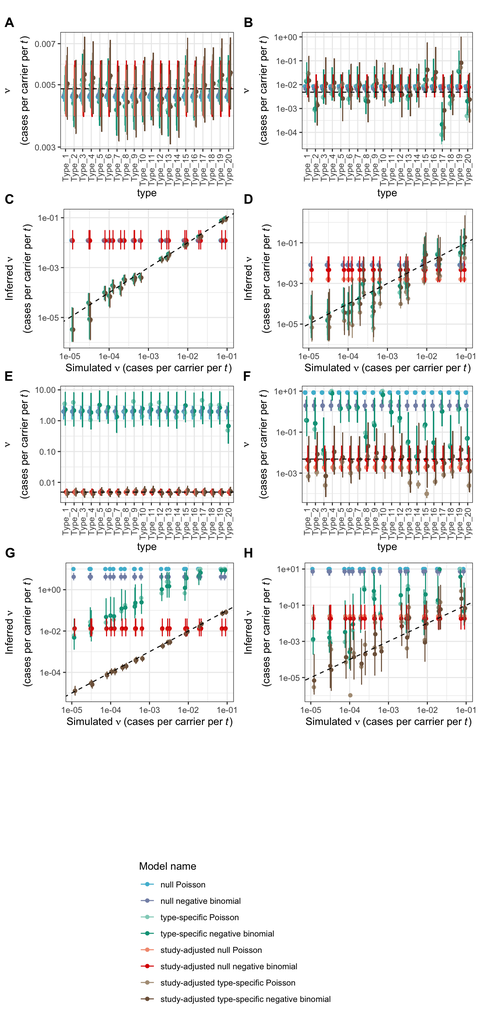

```r
# Save data
#save(null_poisson_bf_comparison,null_poisson_simulation_outputs_df,null_negbin_bf_comparison,null_negbin_simulation_outputs_df,type_specific_poisson_bf_comparison,type_specific_poisson_simulation_outputs_df,type_specific_negbin_bf_comparison,type_specific_negbin_simulation_outputs_df,study_adjusted_poisson_bf_comparison,study_adjusted_poisson_simulation_outputs_df,study_adjusted_negbin_bf_comparison,study_adjusted_negbin_simulation_outputs_df,study_adjusted_type_specific_poisson_bf_comparison,study_adjusted_type_specific_poisson_simulation_outputs_df,study_adjusted_type_specific_poisson_simulation_outputs_df,study_adjusted_type_specific_poisson_bf_comparison,study_adjusted_type_specific_negbin_bf_comparison,study_adjusted_type_specific_negbin_simulation_outputs_df,file = "/Users/ncrouche/Documents/progression_rate_estimation/FOR_RESUB/simulation_output_data.Robj")

# Get all plots
inv_plot_list <- list(
  null_poisson_plot,
  null_negbin_plot,
  type_specific_poisson_plot,
  type_specific_negbin_plot,
  study_adjusted_poisson_plot,
  study_adjusted_negbin_plot,
  study_adjusted_type_specific_poisson_plot,
  study_adjusted_type_specific_negbin_plot
)

no_legend_plots <- list()
for (i in 1:length(inv_plot_list)) {
  no_legend_plots[[i]] <- inv_plot_list[[i]] + theme(legend.position = "none")
}

legend_for_plots <- cowplot::get_legend(null_poisson_plot)

no_leg_plot <- cowplot::plot_grid(plotlist = no_legend_plots,
                                  ncol = 2,
                                  nrow = 5,
                                  labels = "AUTO",
                                  vjust = -0.01) +
      theme(plot.margin = unit(c(1.0,0,0,0), "cm"))

(inv_plot_with_legends <-
  cowplot::plot_grid(no_leg_plot,
                     legend_for_plots,
                     ncol = 1,
                     rel_heights = c(1,0.05)) +
      theme(plot.margin = unit(c(0.0,0,2.5,0), "cm")))
```

```r
ggsave(file="simulations_invasiveness_plots.png", height = 11, width = 8)

ggsave(file="simulations_invasiveness_plots.pdf", height = 11, width = 8)
```

## Plot phi

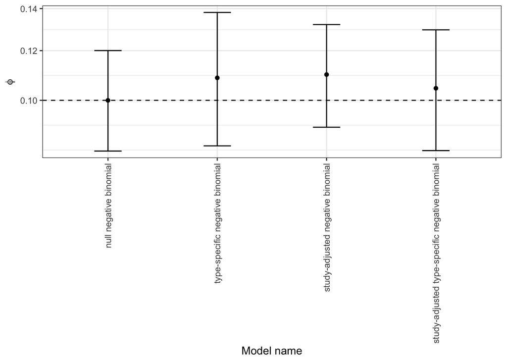

```r
negbin_fits <-
  dplyr::bind_rows(
    null_negbin_simulation_outputs_df %>%
      dplyr::filter(model_name == "null negative binomial") %>%
      dplyr::select(model_name,true_phi,phi,phi_upper,phi_lower) %>%
      dplyr::distinct(),
    type_specific_negbin_simulation_outputs_df %>%
      dplyr::filter(model_name == "type-specific negative binomial") %>%
      dplyr::select(model_name,true_phi,phi,phi_upper,phi_lower) %>%
      dplyr::distinct(),
    study_adjusted_negbin_simulation_outputs_df %>%
      dplyr::filter(model_name == "study-adjusted null negative binomial") %>%
      dplyr::select(model_name,true_phi,phi,phi_upper,phi_lower) %>%
      dplyr::distinct(),
    study_adjusted_type_specific_negbin_simulation_outputs_df %>%
      dplyr::filter(model_name == "study-adjusted type-specific negative binomial") %>%
      dplyr::select(model_name,true_phi,phi,phi_upper,phi_lower) %>%
      dplyr::distinct()
  )

(sim_phi_plot <-
  ggplot(negbin_fits,
        aes(x = model_name,
            y = phi,
            ymin = phi_lower,
            ymax = phi_upper)) +
    geom_point() +
    geom_errorbar(width = 0.25) +
    theme_bw() +
    scale_y_continuous(trans="log10") +
    scale_x_discrete(label = c("null negative binomial",
                                 "type-specific negative binomial",
                                 "study-adjusted negative binomial",
                                 "study-adjusted type-specific negative binomial")
                       ) +
    geom_hline(yintercept = 0.1, linetype = "dashed") +
    ylab(expression(phi)) +
    xlab("Model name") +
    theme(axis.text.x = element_text(angle = 90, vjust = 0.5, hjust = 1))
)
```

```r
ggsave(sim_phi_plot,
       file="simulation_phi_plot.png",
       height = 6,
       width = 6)

ggsave(sim_phi_plot,
       file="simulation_phi_plot.pdf",
       height = 6,
       width = 6)
```